# WQP Parameter and Method exploration

# Harmonizing disparate data

The data from the water quality portal includes a wide range of methods and characteristic names. For example in the “chlorophyll” this can be chlorophyll a, b, or both and retrieved using a variety of methods. To know which methods and characteristic names to keep and use, we must first get a better understanding of the type of data we have.

Here we are harmonizing the entirety of the water quality portal data even though the vast majority of these sites will not be landsat visible. The computation time to do it for a few extra million samples is not onerous and the intermediate mostly harmonized full dataset will likely be useful for other uses.

We’ll start with the easiest first. Secchi depth

# Secchi depth

## Secchi Methods

The nice thing with secchi disk depth methods, is that the name explains the method and their are not really alternative methods so we will not filter this data by sampling or analytical method categories.

## Secchi Unit Harmonization

In many ways, the secchi disk depth measurement is the easiest water quality parameter to harmonize, because there is really only one method for measuring secchi disk depth (it’s in the name after all), and there should always be units of depth (m, ft, inches, cm, etc…). So to harmonize secchi depth measurements we simpy drop all units that are not units of depth and convert all units to a single kind with a lookup table.

```r
#Read in the raw data from '1_wqdata/out'
secchi <- read_feather('1_wqdata/tmp/wqp/all_raw_secchi.feather') %>%
  wqp.renamer()
```

```
## [1] "we dropped 1894 samples because the sample medium was not labeled as Water"
```

```r
#Summarize by characteristic name and unit code and print
secchi %>%
  group_by(parameter,units) %>%
  summarize(count=n()) %>%
  arrange(desc(count)) %>%
  kable(.,'html',caption='All secchi parameter and unit combinations') %>%
  kable_styling() %>%
  scroll_box(width='500px',height='400px')
```

All secchi parameter and unit combinations

| parameter | units | count |
| --- | --- | --- |
| Depth, Secchi disk depth | m | 1736036 |
| Depth, Secchi disk depth | ft | 386408 |
| Depth, Secchi disk depth | cm | 116596 |
| Depth, Secchi disk depth | in | 54382 |
| Depth, Secchi disk depth (choice list) | NA | 39281 |
| Depth, Secchi disk depth | NA | 12037 |
| Secchi Reading Condition (choice list) | NA | 864 |
| Secchi Reading Condition (choice list) | None | 643 |
| Water transparency, Secchi disc | in | 559 |
| Depth, Secchi disk depth (choice list) |  | 428 |
| Depth, Secchi disk depth (choice list) | m | 208 |
| Depth, Secchi disk depth | mg | 187 |
| Depth, Secchi disk depth | ft/sec | 20 |
| Depth, Secchi disk depth (choice list) | None | 13 |
| Depth, Secchi disk depth | deg F | 6 |
| Depth, Secchi disk depth | deg C | 1 |
| Depth, Secchi disk depth | mi | 1 |
| Depth, Secchi disk depth (choice list) | ft | 1 |

### Secchi unit disharmony

Now that we can see all the units we have we can drop non-depth units and make a lookup table to convert all units to meters.

```r
#Create a lookup table of units and conversion factors that we want to keep
secchi.lookup <- tibble(units=c('cm','ft','in','m','mi'),
                        conversion = c(0.01,.3048,0.0254,1,1609.34))

# Do an anti_join to these units so that all units that aren't kept can be highlighted and displayed
secchi.disharmony <- secchi %>%
  anti_join(secchi.lookup,by='units') %>%
  group_by(units) %>%
  summarize(count=n())


secchi.disharmony %>%
  kable(.,'html',caption='The following secchi measurements
        were dropped because the units do not make sense') %>%
  kable_styling() %>%
  scroll_box(width='500px',height='400px')
```

The following secchi measurements were dropped because the units do not make sense

| units | count |
| --- | --- |
|  | 428 |
| deg C | 1 |
| deg F | 6 |
| ft/sec | 20 |
| mg | 187 |
| None | 656 |
| NA | 52182 |

### Secchi unit harmony in meters

```r
#Join secchi by unit name and then multiply by conversion factor to get meters
secchi.harmonized <- secchi %>%
  inner_join(secchi.lookup,by='units') %>%
  mutate(harmonized_parameter = 'secchi',
         harmonized_value=value*conversion,
         harmonized_unit='meters')
```

Next easiest is TSS

# TSS

This [paper](https://water.usgs.gov/osw/pubs/WRIR00-4191.pdf) is really useful for exploring this data. In this paper, the USGS directly compares estimates of Suspended Sediment Concentration (SSC) and Total Suspended Solids (TSS). The primary difference between these methods, as laid out in this paper, is that SSC estimates the mass of suspended solids in a sample volume, by drying out the entire sample without subsampling the water volume. TSS methods often involve some form of subsampling of the total water volume. The paper highlights that while many estimates of TSS and SSC are essentially the same, samples with high sand content show systematic bias in TSS estimates. For our purposes, we have no apriori way to distinguish samples with high or low sand, so we have made the choice to assume that measurements of SSC and TSS are, over the bulk of samples, the same. We use the term “TSS” from here on to describe this data that is both SSC and TSS.

```r
#Read in the raw data from '1_wqdata/out'
tss <- read_feather('1_wqdata/out/wqp/all_raw_tss.feather') %>%
  wqp.renamer()
```

```
## [1] "we dropped 88556 samples because the sample medium was not labeled as Water"
```

```r
#Summarize by characteristic name and unit code
tss %>%
  group_by(parameter,units) %>%
  summarize(count=n()) %>%
  arrange(desc(count)) %>%
  kable(.,'html',caption='All tss parameter and unit combinations') %>%
  kable_styling() %>%
  scroll_box(width='500px',height='400px')
```

All tss parameter and unit combinations

| parameter | units | count |
| --- | --- | --- |
| Total suspended solids | mg/l | 2829187 |
| Suspended Sediment Concentration (SSC) | mg/l | 1156062 |
| Suspended sediment concentration (SSC) | % | 719493 |
| Total suspended solids | NA | 235106 |
| Fixed suspended solids | mg/l | 220774 |
| Suspended sediment concentration (SSC) | mg/l | 12041 |
| Fixed suspended solids | NA | 9354 |
| Suspended Sediment Concentration (SSC) | % | 6758 |
| Suspended Sediment Concentration (SSC) | NA | 5393 |
| Total suspended solids | % | 4735 |
| Suspended sediment concentration (SSC) | NA | 3489 |
| Total suspended solids | ppm | 1680 |
| Total suspended solids | tons/day | 529 |
| Total suspended solids | ug/l | 476 |
| Total suspended solids |  | 35 |
| Total suspended solids | kg | 29 |
| Total suspended solids | None | 16 |
| Total suspended solids | count | 1 |
| Total suspended solids | NTU | 1 |

## TSS methods

Now that we have made the decision to call SSC and TSS interchangeable depsite their slight methodological differences, we need to explore the various methods used to get TSS or SSC concentration estimates. Unlike with issues with units, we can not harmonize our way out of methods that don’t make sense. So instead we will be filtering out these methods.

There are essentially two important methods for thinking about TSS and SSC. The field method used to collect the water sample and the analytical method used to weigh out suspended sediment and total water volume. The sample methods are extremely verbose and varied, but mostly boil down to some version of sample collected in bottle of water. For posterity a table of sample method is reproduced here, but we do not filter based on sample method.

### TSS sample methods

Many of these methods refer to other documents that were used as a protocol for sampling (EPA METHOD or USGS), but these also are versions of collecting water with a bottle, pump, or depth sampling equipment.

```r
tss %>%
  group_by(sample_method) %>%
  summarize(count=n()) %>%
  arrange(desc(count)) %>%
  kable(.,'html',caption='All tss sample methods and their count (678 methods)') %>%
  kable_styling() %>%
  scroll_box(width='600px',height='400px')
```

All tss sample methods and their count (678 methods)

| sample_method | count |
| --- | --- |
| USGS | 1702606 |
| Surface | 322724 |
| Grab sample. Submerge and fill a water sampling vessel, or sample directly into the sample bottle provided by the an… | 208770 |
| Point sample | 184816 |
| Equal width increment (ewi) | 177421 |
| Water Grab Sampling | 146899 |
| Grab | 128011 |
| G | 93474 |
| GRAB | 89945 |
| Ambient Water Quality Monitoring QAPP and SOP | 84467 |
| Total Suspended Solids/Volatile Suspended Sample Filtration, Processing & Storage T | 82854 |
| Unknown | 68398 |
| Multiple verticals | 61189 |
| GRAB SAMPLE | 55010 |
| SJR-SOP | 54918 |
| Equal discharge increment (edi) | 51762 |
| Total Suspended Solids/Volatile Suspended Sample Filtration, Processing & Storage | 49191 |
| Grab Sample | 46873 |
| ADEM SOPs-2000 Series-Surface Water | 44394 |
| STD_SC | 43858 |
| Water_Grab | 41246 |
| GRAB | 41147 |
| Grab sample (dip) | 38035 |
| SOP For The Collection And Preservation Of Stream And River Grab Samples For Chemical And Biological Analysis. | 37311 |
| STANDARD | 36280 |
| SuspSed; Pumping - stream sample using a pumping mechanism | 35832 |
| Chesapeake Bay Program | 35522 |
| Water Grab Sample | 33391 |
| OEPA Surface Water Sample Collection Method | 33110 |
| Standard UHL Sampling Procedure - Grab Samples | 29319 |

[output cut: 648 more lines]

### TSS analytical methods

Unlike with secchi disk depth measurements, there are a variety of analytical methods available to measure TSS. Many of these should provide similar results, but some can be used to highlight potential erroeneous data entry (Phosphorous content should not be a method of TSS calculation), but many of them are simply labeled by a state or federal protocol number, making trimming and evaluating these various methods difficult. Below is a table of all possible analytical methods and their count

```r
tss %>%
  group_by(analytical_method) %>%
  summarize(count=n()) %>%
  arrange(desc(count)) %>%
  kable(.,'html',caption='All tss analytical methods and their count') %>%
  kable_styling() %>%
  scroll_box(width='600px',height='400px')
```

All tss analytical methods and their count

| analytical_method | count |
| --- | --- |
| NA | 2253048 |
| Total Suspended Solids in Water | 660620 |
| Non-Filterable Residue - TSS | 648298 |
| Residue by Evaporation and Gravimetric | 249769 |
| Sediment conc by filtration | 161882 |
| Sus solids, wat, 105C,wt (NWQL) | 108994 |
| analyticTSS_101 | 105332 |
| Computation by NWIS algorithm | 84571 |
| Sediment conc from size analysis | 74063 |
| Sediment conc by evaporation | 72438 |
| Volatile Residue | 68397 |
| analyticTSS_GRAVIMETRIC; DRIED AT 103-105 C | 67208 |
| Wet sieve | 63916 |
| RESIDUE, TOTAL NONFILTRABLE (MG/L) | 53434 |
| Total Suspended Solids | 46581 |
| 160.2 | 32124 |
| V A tube | 28102 |
| Residue | 27186 |
| Fixed and Volatile Solids in Water | 26565 |
| SM2540D | 24720 |
| SM 2540D | 22725 |
| Unkn Lab Proc | 20850 |
| Dry sieve | 20609 |
| EPA 160.4 | 17934 |
| UNKOWN | 15259 |
| UNKNOWN | 14844 |
| Effluent monitoring sample | 14835 |
| Historic | 14695 |
| Historic Procedure | 13486 |
| SM 2540 D | 11511 |

[output cut: 163 more lines]

Many of these analytical methods are sensible and we can keep the majority of the data. One glaring issue is that more than 2 million observations have an analytical method of NA. What should we do with these samples? Throw out half of our data because the method is not verifiable? Or keep it knowing that some of the data might be using incompatable methods.

#### TSS removing nonsensical analytical TSS methods

To keep the most data possible, we are making the explicit choice to only exclude methods that are clearly wrong (Ammonia content is not an appropriate TSS method). This means we are keeping the more than 2 million observatiosn with an analytical method of NA. While there are a variety of methods for estimating TSS, they can only differ so much, given that the primary goal is to get the mass of suspended matter per unit water volume. We assume most of these NA measurements were simply not recorded because the method used was a well-known method (like sediment concentratino by filtration).

The code below is essentially a list of parameters we do not want to keep.

```r
#There are a lot of parameter codes so we are just going to use a grepl command with key words that definitely disqualify the sample

non.sensical.tss.methods <- tss %>%
  filter(grepl("Oxygen|Nitrogen|Ammonia|Metals|E. coli|Carbon|Anion|Cation|Phosphorus|Silica|PH|HARDNESS|Nutrient|Turbidity|Temperature|Nitrate|Conductance|Alkalinity|Chlorophyll",analytical_method,ignore.case=T))


tss.filtered <- tss %>%
  filter(!analytical_method %in% non.sensical.tss.methods$analytical_method)

print(paste('We dropped', round(nrow(non.sensical.tss.methods)/nrow(tss)*100,2),'% of samples, because the method used did not make sense. These methods are:'))
```

```
## [1] "We dropped 0.3 % of samples, because the method used did not make sense. These methods are:"
```

```r
p(unique(non.sensical.tss.methods$analytical_method),wrap='',sep=' - ') #Nice function for printing long vectors horizontally separated by dash
```

```
## [1] "Nutrient analyses from water samples - Sedigraph - Metals in Waters by ICP/MS - Determination of Inorganic Anions by Ion Chromatography - PH TEMPERATURE BY SM 2550B-00 - HARDNESS IN WATER BY EDTA TITRATION - Turbidity in Water - METALS - Enzyme substrate assay for measuring total coliforms a…
```

### TSS depth of sampling

For TSS some sites also have the water depth of sample, which is very useful for validating whether or not the sample will reflect satellite observation of the same water parcel. However, most of the data doesn’t have this depth of sampling data and it requires a bit of its own munging, since the sampling depth comes down in a range of units. Here we make the choice to not filter by depth of sample, but we show a histogram of sampling depths for sites that do have it. Most are near surface < 5 m.

```r
#Define a depth lookup table to convert all depth data to meters.
depth.lookup <- tibble(sample_depth_unit=c('cm','feet','ft','in','m','meters','None'),
                       depth_conversion=c(1/100,.3048,.3048,0.0254,1,1,NA))

#Join depth lookup table to tss data
tss.depth <- inner_join(tss,depth.lookup,by=c('sample_depth_unit')) %>%
  #Some depth measurements have negative values (assume that is just preference)
  #I also added .01 meters because many samlples have depth of zero assuming they were
  # taken directly at the surface
  mutate(harmonized_depth=abs(sample_depth*depth_conversion)+.01)

# We lose lots of data by keeping only data with depth measurements
print(paste('If we only kept samples that had depth information we would lose',round((nrow(tss)-nrow(tss.depth))/nrow(tss)*100,1),'% of samples'))
```

```
## [1] "If we only kept samples that had depth information we would lose 75.5 % of samples"
```

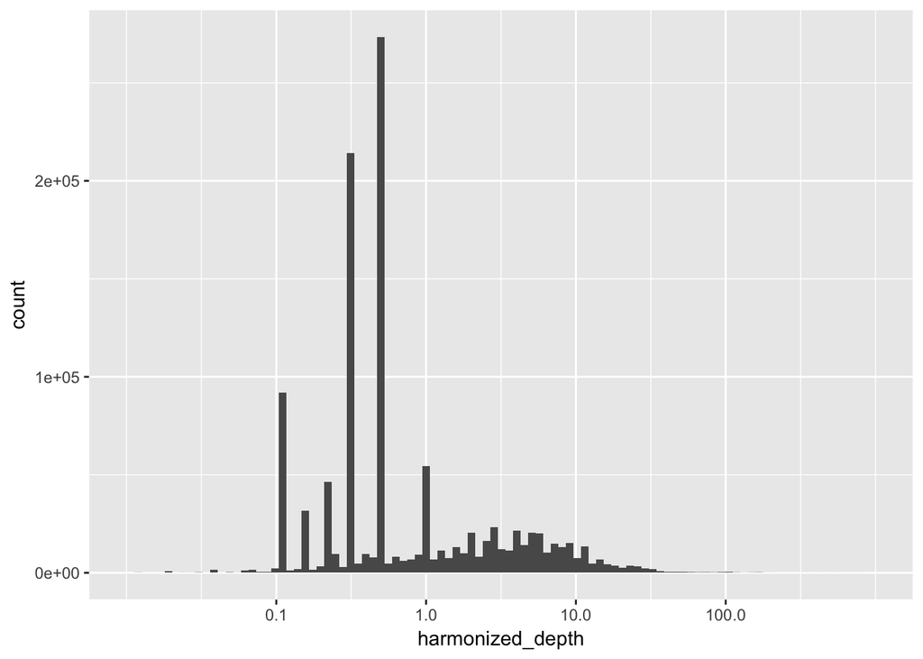

```r
ggplot(tss.depth,aes(x=harmonized_depth)) +
  geom_histogram(bins=100) +
  scale_x_log10(limits=c(0.01,10^3),breaks=c(.1,1,10,100))
```

If we ignore all these additional data streams and simply assume SSC and TSS are generally near surface water samples collected with compatible field sampling and analytical methods. Then we can simply get rid of samples that have nonsensical units.

## TSS Unit Harmonization

### TSS disharmony

As with secchi disk depth, we expect certain units to be associated with total suspended solids or suspended sediment concentration. These include mass per volume measurements like: mg/l, g/l, ug/l and others.

TSS does come with one less obvious parameter which is %. Any sample with a % unit is most commonly a sample where suspended sediments were split into particle size fractions. The relative proportion of clay, silt, and sand can have important impacts on the reflectance properties of water, so this is a useful parameter to keep, though it will require some exploration, using the additional data column that we relabeld as “particle_size.”

#### TSS particle size fractionation

```r
#Select only units for %
tss.p <- tss %>%
  filter(units == '%')

#look at the breakdown of particle sizes
tss.p %>%
  group_by(particle_size) %>%
  summarize(count=n()) %>%
  kable(.,'html',caption='All particle size fractions and their count') %>%
  kable_styling() %>%
  scroll_box(width='600px',height='400px')
```

All particle size fractions and their count

| particle_size | count |
| --- | --- |
| < 0.001 mm | 655 |
| < 0.002 mm | 32594 |
| < 0.004 mm | 44399 |
| < 0.008 mm | 24521 |
| < 0.016 mm | 42984 |
| < 0.031 mm | 23248 |
| < 0.0625 mm | 327984 |
| < 0.062mm | 172 |
| < 0.063 mm | 15 |
| < 0.09 mm | 86 |
| < 0.125 mm | 77011 |
| < 0.18 mm | 86 |
| < 0.25 mm | 68509 |
| < 0.355 mm | 80 |
| < 0.5 mm | 52289 |
| < 0.71 mm | 19 |
| < 1 mm | 20561 |
| < 1.4 mm | 1 |
| < 128 mm | 15 |
| < 16 mm | 16 |
| < 2 mm | 4189 |
| < 256 mm | 15 |
| < 3.35 mm | 2 |
| < 4 mm | 172 |
| < 63 mm | 15 |
| < 8 mm | 27 |
| sands | 1137 |
| silts and clays | 1140 |
| NA | 9044 |

```r
#Keep only the sand fraction data (~50% of the data)
sand.harmonized  <- tss.p %>%
  filter(particle_size %in%  c('< 0.0625 mm','sands')) %>%
  mutate(conversion=NA,
         harmonized_parameter='p.sand',
         harmonized_value=value,
         harmonized_unit='%')
```

#### TSS dropping bad units

Now that we have split out the TSS values that had “%” units, we can deal with and drop the more nonsensical or missing units. The table below will also print out the number of “%” observations that we drop, but, remember, we kept about half of these in the above code.

Here we will convert all remaining sediment values to units of mg/L and drop any non mass/volume units.

```r
#Make a tss lookup table
tss.lookup <- tibble(units=c('mg/l','g/l','ug/l','ppm'),
                        conversion = c(1,1000,1/1000,1))


tss.disharmony <- tss %>%
  anti_join(tss.lookup,by='units') %>%
  filter(!particle_size %in% c('< 0.0625 mm','sands')) %>%
  group_by(units) %>%
  summarize(count=n())



knitr::kable(tss.disharmony,caption='The following TSS measurements were dropped because the units do not make sense')
```

The following TSS measurements were dropped because the units do not make sense

| units | count |
| --- | --- |
|  | 35 |
| % | 401865 |
| count | 1 |
| kg | 29 |
| None | 16 |
| NTU | 1 |
| tons/day | 529 |
| NA | 253293 |

### TSS harmony in mg/l

```r
#Join to the lookup table and harmonize units

tss.harmonized <- tss %>%
  inner_join(tss.lookup,by='units') %>%
  mutate(harmonized_parameter = 'tss',
         harmonized_value=value*conversion,
         harmonized_unit='mg/l') %>%
  #Change harmonized parameter to tis for parameter "fixed suspended solids"
  mutate(harmonized_parameter = ifelse(parameter == 'Fixed suspended solids','tis',harmonized_parameter))
```

# DOC

Dissolved organic carbon (DOC) is a complex series of parameters, methods, and unit combinations. We will not be examining particulate organic carbon, total organic carbon, or even colored dissolved organic matter (mostly because there is so few samples in the WQP with cdom).

First let’s read in the data.

```r
#Summarize by characteristic name and unit code
doc <- read_feather('1_wqdata/out/wqp/all_raw_doc.feather') %>%
  wqp.renamer() %>%
  #Remove trailing white space in labels
  mutate(units = trimws(units))
```

```
## [1] "we dropped 63589 samples because the sample medium was not labeled as Water"
```

### DOC sample fraction and sample methods

The water quality portal does not have a category for “Dissolved Organic Carbon,” so we pulled three parameter names that might capture this category. ‘Total Carbon’, ‘Organic Carbon’, and ‘Non-purgeable Organic Carbon (NPOC)’. For our purposes NPOC and Organic Carbon are exchnageable parameter names. In this data, there is a key column that we labeled ‘fraction’, which declares what fraction of the carbon pool is being reported. For purposes of this work, we are only keeping the fraction that indicates dissolved organic carbon, which can include fraction names like ‘Dissolved’ or ‘Filterable.’ The full list of fraction names and parameter names.

```r
doc %>%
  group_by(fraction) %>%
  summarize(count=n()) %>%
  arrange(desc(count)) %>%
  kable(.,'html',caption='All doc sample fraction names and their count') %>%
  kable_styling() %>%
  scroll_box(width='600px',height='400px')
```

All doc sample fraction names and their count

| fraction | count |
| --- | --- |
| Total | 1173924 |
| Dissolved | 650802 |
| Non-Filterable (Particle) | 137705 |
| Suspended | 88550 |
| NA | 3616 |
| Bed Sediment | 2968 |
| Filterable | 2034 |
| Filtered, lab | 1290 |
| Unfiltered | 725 |
|  | 241 |
| Organic | 144 |
| Filtered, field | 129 |
| Acid Soluble | 1 |

#### Keeping only Dissolved Fraciton

Here we subset the data to only include the data that we know is the Dissolved Organic Carbon pool. So far this is without regard to differences in analytical method.

```r
doc.fraction.names <- c('Dissolved','Filterable','Filtered, lab','Filtered, field')
doc.dissolved <- doc %>%
  filter(fraction %in% doc.fraction.names)


print(paste('we dropped',nrow(doc)-nrow(doc.dissolved),'samples because they were not labeled as dissolved'))
```

```
## [1] "we dropped 1407874 samples because they were not labeled as dissolved"
```

## DOC methods

Here, we’ll explore method, and unit combinations and trim the data down a lot to keep only the most useful data.

### DOC sample methods

As with TSS we are not going to filter our DOC data by sample method but the table of sample methods are provided here.

```r
doc.dissolved %>%
  group_by(sample_method) %>%
  summarize(count=n()) %>%
  arrange(desc(count)) %>%
  kable(.,'html',caption='All doc sample methods and their count (678 methods)') %>%
  kable_styling() %>%
  scroll_box(width='600px',height='400px')
```

| sample_method | count |
| --- | --- |
| Surface | 118962 |
| USGS | 114198 |
| Dissolved Nutrient Sample Filtration & Collection T | 65548 |
| Grab Sample Collected With A Stainless Bucket | 39649 |
| SJR-SOP | 27046 |
| Equal width increment (ewi) | 25430 |
| Dissolved Nutrient Sample Filtration & Collection | 22921 |
| Dissolved Nutrient Sample Filtration & Collection B | 21490 |
| Multiple verticals | 20112 |
| Grab Sampling | 17770 |
| Generic SJRWMD Sample Collection Procedure | 16201 |
| Grab sample (dip) | 13898 |
| Grab | 13226 |
| G | 9790 |
| GRAB | 8166 |
| Standard Routine Sample Collection | 6778 |
| Land Collections Directly from Water Source | 5248 |
| Unknown | 4784 |
| Grab Sample Collected With A Water Bottle | 4578 |
| Dissolved Nutrient Sample Filtration & Collection A | 4028 |
| Water_Grab | 3943 |
| Equal discharge increment (edi) | 3602 |
| Land Station Collection from Bridge | 3462 |
| Boat Station Collections | 3456 |
| Point sample | 3345 |
| NPS_LEGACY | 3215 |
| ISU Lake Sample Collection Procedure | 3181 |
| Dissolved Nutrient Sample Filtration & Collection K | 3037 |
| Grab sample. Submerge and fill a water sampling vessel, or sample directly into the sample bottle provided by the an… | 2930 |
| Automated sample collection | 2517 |

[output cut: 170 more lines]

### DOC analytical method

After removing the non “dissolved” fraction of carbon observations we are left with ~ 650,000 samples. Here we will remove analytical methods that explicitly do not make sense. As with TSS we will keep samples with analytical methods labeled as NA, assuming that they were done in a way that is exchangeable with other methods. This is a potentially erroneous assumption.

```r
doc.dissolved %>%
  group_by(analytical_method) %>%
  summarize(count=n()) %>%
  arrange(desc(count)) %>%
  kable(.,'html',caption='All DOC analytical methods') %>%
  kable_styling() %>%
  scroll_box(width='600px',height='400px')
```

All DOC analytical methods

| analytical_method | count |
| --- | --- |
| NA | 109126 |
| Total Organic Carbon by Combustion | 81149 |
| Total Organic Carbon by Combustion-Infrared Method | 65403 |
| analyticDOC_101 | 47422 |
| analyticDOC_102 | 42339 |
| DOC, 0.45u silver, persulfate IR | 38282 |
| WET OXIDATION METHOD | 33576 |
| DOC,0.45um cap,acid,persulfateIR | 31858 |
| DOC, UV/persulfate/IR (USGS-NYL) | 29647 |
| analyticDOC_L01N | 27263 |
| UV OR HEATED PERSULFATE OXIDATION | 26096 |
| Total Organic Carbon in Water- Ultraviolet Oxidation Method | 24469 |
| Low Level Total Organic Carbon in Water | 17763 |
| DOC, 0.7um GFF,acid,persulfateIR | 17546 |
| Total Organic Carbon by High-Temperature Combustion Method | 15524 |
| DOC, persulfate oxidation & IR | 7778 |
| Organic Carbon in Water | 4382 |
| DOC, UV/persulfate (NYWSC; ALSC) | 3884 |
| Dissolved organic carbon by Teledyne-Tekmar Phoenix 8000 TOC Analyzer | 2951 |
| SM5310B | 2692 |
| Organic-C, combustion-IR method | 2420 |
| DOC, EPA method | 2375 |
| C | 2214 |
| EPA 415.1M | 1747 |
| Elemental Analysis Isotope Ratio Mass Spectometry | 1557 |
| Total Organic Carbon in Water and Waste | 1489 |
| CARBON, DISSOLVED ORGANIC (MG/L AS C) | 1392 |
| Historic Procedure | 1148 |
| SM 5310 B | 1024 |
| Dissolved Organic Carbon by Dohrmann DC-80 | 1017 |

[output cut: 63 more lines]

#### DOC removing nonsensical analytical methods

```r
doc.nonsense.methods <- doc.dissolved %>%
  filter(grepl("Oxygen|Nitrogen|Ammonia|Metals|E. coli|Anion|Cation|Phosphorus|Silica|PH|HARDNESS|Nutrient|Turbidity|Nitrate|Conductance|Alkalinity|Chlorophyll|Solids",analytical_method,ignore.case=T)) %>%
  filter(analytical_method != 'Temperature')


doc.filtered <- doc.dissolved %>%
  filter(!analytical_method %in% doc.nonsense.methods$analytical_method)

print(paste('We dropped', round(nrow(doc.nonsense.methods)/nrow(doc)*100,2),'% of samples, because the method used did not make sense. These methods are:'))
```

```
## [1] "We dropped 0.15 % of samples, because the method used did not make sense. These methods are:"
```

```r
p(unique(non.sensical.tss.methods$analytical_method),wrap='',sep=' - ')
```

```
## [1] "Nutrient analyses from water samples - Sedigraph - Metals in Waters by ICP/MS - Determination of Inorganic Anions by Ion Chromatography - PH TEMPERATURE BY SM 2550B-00 - HARDNESS IN WATER BY EDTA TITRATION - Turbidity in Water - METALS - Enzyme substrate assay for measuring total coliforms a…
```

## DOC Units

As with TSS we generally expect DOC units to be in units of mass per unit volume, but we have many more possible variations of methods used to extract DOC values.

```r
doc.filtered %>%
  group_by(units) %>%
  summarize(count=n()) %>%
  arrange(desc(count)) %>%
  kable(.,'html',caption='All doc units') %>%
  kable_styling() %>%
  scroll_box(width='600px',height='400px')
```

All doc units

| units | count |
| --- | --- |
| mg/l | 644456 |
| NA | 4742 |
| ppm | 902 |
| % | 521 |
| None | 510 |
| ug/l | 32 |

Wow that is great. The vast majority of data is in a sensible unit (mg/L). We’ll harmonize the remaining mass/volume units (ppm/ug/L) and drop the NAs and % units. Looks like sampling by `sample fraction` column cuts out a lot of the potential disharmony in units.

### DOC unit disharmony

```r
#Setup a lookup table so that final units are all in mg/L.
doc.lookup <- tibble(units=c('mg/l','ppm','ug/l'),
                        conversion = c(1,1,.001))

doc.unit.drop <- doc.filtered %>%
  anti_join(doc.lookup,by='units')

print(paste('We dropped',nrow(doc.unit.drop),'DOC observations because the units do not make sense'))
```

```
## [1] "We dropped 5773 DOC observations because the units do not make sense"
```

## DOC harmony

The final step. Convert all convertable units to mg/l!

```r
doc.harmonized <- doc.filtered %>%
  inner_join(doc.lookup,by='units') %>%
  mutate(harmonized_parameter = 'doc',
         harmonized_value=value*conversion,
         harmonized_unit='mg/L')
```

# Chlorophyll

Chlorophyll concentration is a good proxy for algal biomass, but it may be the hardest parameter to harmonize because of a large array of diverse methods and measurements. Fist let’s drop measurements that were not water samples (benthic chlorophyll)

```r
#Read in the raw data from '1_wqdata/out'
chl <- read_feather('1_wqdata/out/wqp/all_raw_chlorophyll.feather') %>%
  wqp.renamer() %>%
  #Remove trailing white space in labels
  mutate(units = trimws(units))
```

```
## [1] "we dropped 29068 samples because the sample medium was not labeled as Water"
```

## Chlorophyll a only

Here we are reducing the harmonization difficulty associated with chlorphyll by only keeping Chlorophyll a measurements, which is by far the most common measurement. But let’s first look at all the various chlorophyll names we pulled down from the water quality portal.

```r
chl %>%
   group_by(parameter) %>%
   summarize(count=n()) %>%
   arrange(desc(count)) %>%
   kable(.,'html',caption='All chlorophyll parameter names and their count') %>%
   kable_styling() %>%
   scroll_box(width='600px',height='400px')
```

All chlorophyll parameter names and their count

| parameter | count |
| --- | --- |
| Chlorophyll a | 1400300 |
| Chlorophyll a (probe relative fluorescence) | 504517 |
| Chlorophyll a, corrected for pheophytin | 476745 |
| Chlorophyll b | 299601 |
| Chlorophyll a, uncorrected for pheophytin | 262160 |
| Chlorophyll c | 248455 |
| Chlorophyll | 153659 |
| Chlorophyll/Pheophytin ratio | 88402 |
| Chlorophyll a (probe) | 77291 |
| Chlorophyll a, free of pheophytin | 46518 |
| Chlorophyll a - Phytoplankton (suspended) | 2673 |
| Chlorophyll a - Periphyton (attached) | 2323 |

### Chlorophyll a parameter disharmony

We are dropping the below parameter names

```r
chl.a.names <- c('Chlorophyll a','Chlorophyll a (probe relative fluorescence)','Chlorophyll a, corrected for pheophytin','Chlorophyll a (probe)','Chlorophyll a, free of pheophytin', 'Chlorophyll a - Phytoplankton (suspended)')

chl %>%
  filter(!parameter %in% chl.a.names) %>%
  group_by(parameter) %>%
  summarize(count=n()) %>%
  kable(.,'html',caption='All dropped chlorophyll parameter names and their count') %>%
  kable_styling() %>%
  scroll_box(width='600px',height='400px')
```

All dropped chlorophyll parameter names and their count

| parameter | count |
| --- | --- |
| Chlorophyll | 153659 |
| Chlorophyll a - Periphyton (attached) | 2323 |
| Chlorophyll a, uncorrected for pheophytin | 262160 |
| Chlorophyll b | 299601 |
| Chlorophyll c | 248455 |
| Chlorophyll/Pheophytin ratio | 88402 |

### Chlorophyll a keep

```r
chl.a <- chl %>%
  filter(parameter %in% chl.a.names)
```

## Chlorophyll a sample fraction

Now that we are only keeping the chlorophyll a fraction, we can start removing disharmony in the sample fraction, analytical method, and units categories. We’ll start with the sample fraction

### Chlorophyll a all fractions

```r
chl.a %>%
   group_by(fraction) %>%
   summarize(count=n()) %>%
   arrange(desc(count)) %>%
   kable(.,'html',caption='All chlorophyll sample methods and their count') %>%
   kable_styling() %>%
   scroll_box(width='600px',height='400px')
```

All chlorophyll sample methods and their count

| fraction | count |
| --- | --- |
| Total | 1184690 |
| NA | 622174 |
| Filtered, lab | 210832 |
|  | 193784 |
| Non-Filterable (Particle) | 180975 |
| Filterable | 80012 |
| Suspended | 13150 |
| Non-filterable | 10107 |
| None | 6477 |
| Dissolved | 3970 |
| Extractable | 915 |
| Unfiltered | 765 |
| Comb Available | 146 |
| Filtered, field | 41 |
| <Blank> | 4 |
| Acid Soluble | 2 |

This table highlights essentially four dominant categories for chlorophyll a sample fraction: Total (not-filtered), Filtered, Particle, and NA. The NA category is the most concenrting as this makes up almost 1/4 of the remaining data. There is some chance that downstream `analytical_method` cleaning will help clarify the NA category, but we won’t know that until later downstream, so for now we will keep NA. Next, we need to decide which type of Chlorophyll measurements to keep, which given that most of the data is either total or dissolved, we will keep both. [Previous work](https://epic.awi.de/16281/1/Kne2007b.pdf) has shown that the filtering on Chlorophyll a samples captures 10-20% of the chlorophyll. Given the scope of this project and similar decisisons made between SSC and TSS, we are electing to combine Total and Dissolved chlorophyll a into one category and drop the particle fraction.

### Chlorophyll fraction keep

```r
chl.particles <- c('Non-Filterable (Particle)','Suspended','Non-filterable','<Blank>','Acid Soluble')

chl.a.fraction <- chl.a %>%
  filter(!fraction %in% chl.particles)
```

## Chlorophyll a Methods

### Chlorophyll a sample methods

As with all other parameters we are not filtering by sample method

```r
chl.a.fraction %>%
  group_by(sample_method) %>%
  summarize(count=n()) %>%
  arrange(desc(count)) %>%
  kable(.,'html',caption='All chlorophyll sample methods and their count') %>%
  kable_styling() %>%
  scroll_box(width='600px',height='400px')
```

All chlorophyll sample methods and their count

| sample_method | count |
| --- | --- |
| LG301 | 298183 |
| GRAB | 256296 |
| Surface | 203533 |
| NA | 96273 |
| Lake surface 2m depth-integrated sampling. Lower a 2-meter-long, 2-inch-diameter PVC pipe vertically into the water, … | 91981 |
| USGS | 91904 |
| SJR-SOP | 91898 |
| Unknown | 91075 |
| G | 62699 |
| Grab sample. Submerge and fill a water sampling vessel, or sample directly into the sample bottle provided by the an… | 53263 |
| Shallow Water Continuous Monitoring in Tidal Potomac | 49169 |
| Garden hose composite | 39879 |
| WATER GRAB SAMPLE | 38005 |
| Grab | 37733 |
| LEGACY | 32746 |
| SOP-1 | 31250 |
| Towed CTD recording both up and down | 30239 |
| SOP | 29724 |
| ADEM SOPs-2000 Series-Surface Water | 29340 |
| Ambient Water Quality Monitoring QAPP and SOP | 26742 |
| Grab Sample Collected With A Stainless Bucket | 25615 |
| Lake depth point sampling. Lake water is sampled at a discrete depth in the water column using a vertical Kemmerer- … | 20576 |
| UHL001 | 17656 |
| FL DEP Field Sample Collection DEP SOP 01-001 | 16644 |
| SWFWMD SOP’s for the Collection of Water Quality Samples | 15565 |
| Grab Sample | 14778 |
| Generic SJRWMD Sample Collection Procedure | 14601 |
| SP-001 | 14488 |
| Standard UHL Sampling Procedure - Grab Samples | 13293 |
| SP-01 | 12832 |

[output cut: 362 more lines]

### Chlorophyll a analytical methods

```r
chl.a.fraction %>%
  group_by(analytical_method) %>%
  summarize(count=n()) %>%
  arrange(desc(count)) %>%
  kable(.,'html',caption='All chlorophyll analytical methods and their count') %>%
  kable_styling() %>%
  scroll_box(width='600px',height='400px')
```

All chlorophyll analytical methods and their count

| analytical_method | count |
| --- | --- |
| NA | 845492 |
| Chlorophyll a-b-c Determination | 431627 |
| Operating the Seabird CTD | 378767 |
| In-Vitro Determination of Chlorophyll | 194723 |
| MONOCHROMATIC; SPECTROPHOTOMETRIC | 192844 |
| CONTACT VADEQ FOR DETAILS | 49161 |
| Analysis of Chlorophyll in Periphyton and Plankton | 29523 |
| CHLOROPHYLL-A UG/L SPECTROPHOTOMETRIC ACID. METH. | 24445 |
| Chlorophyll a-b-c Determination by fluorometer | 17219 |
| Chlorophyll, phytoplankton, HPLC | 15482 |
| Plant pigments, sonication & 445 | 9745 |
| UNKOWN | 9710 |
| FLUOROMETRIC; IN-VITRO CHLOROPHYLL A | 8867 |
| Chlorophyll a-b-c Determination by spectrophotometer | 8542 |
| Standard Methods for the Examination of Water and Wastewater | 8501 |
| FLUOROMETIC CHLOROPHYLL USING PROBE | 7397 |
| Zooplankton Counting Techniques | 5793 |
| Chlorophyll a | 4887 |
| USEPA 445 | 4339 |
| Chlorophyll a,phyto,fluorometric | 4234 |
| SM 10200 H-2b | 3451 |
| Chlorophyll a, corrected for pheophytin | 3253 |
| Chlorophyll a, phytoplankton | 3004 |
| YSI6025 | 3001 |
| Chlorophylls and Pheopigments in Phytoplankton by Spectrophotometry | 2818 |
| CHLOROPHYLL A | 2340 |
| QA Plan #900456 | 2312 |
| STANDARD METHODS 10200(2)(B) - CHLOROPHYLL A, PHAEOPHYTIN CORRECTION METHOD | 2204 |
| Lake Trafford | 2144 |
| Chloroph | 2027 |

[output cut: 71 more lines]

#### Chlorophyll a removing nonsensical analytical methods

There are quite a few different analytical methods for chlorophyll analysis. Unfortunately the most common category is NA. As with previous parameters we can use this category to simply remove clearly non-sensical methods and keep all others including NA and blank.

```r
chl.a.nonsense.methods <- chl.a.fraction %>%
  filter(grepl("Oxygen|Nitrogen|Ammonia|Metals|Anion|Cation|Phosphorus|Silica|HARDNESS|Nutrient|Turbidity|Nitrate|Conductance|Alkalinity|Solids",analytical_method,ignore.case=T)) %>%
  filter(analytical_method != 'Temperature',
         analytical_method != 'PH')

chl.filtered <- chl.a.fraction %>%
  filter(!analytical_method %in% chl.a.nonsense.methods$analytical_method)

print(paste('We dropped', round(nrow(chl.a.nonsense.methods)/nrow(chl)*100,2),'% of samples, because the method used did not make sense. These methods are:'))
```

```
## [1] "We dropped 0.33 % of samples, because the method used did not make sense. These methods are:"
```

```r
p(unique(non.sensical.tss.methods$analytical_method),wrap='',sep=' - ')
```

```
## [1] "Nutrient analyses from water samples - Sedigraph - Metals in Waters by ICP/MS - Determination of Inorganic Anions by Ion Chromatography - PH TEMPERATURE BY SM 2550B-00 - HARDNESS IN WATER BY EDTA TITRATION - Turbidity in Water - METALS - Enzyme substrate assay for measuring total coliforms a…
```

## Chlorophyll a units

As with TSS and DOC we generally expect Chlorophyll a units to be in units of mass per unit volume.

```r
chl.filtered %>%
  group_by(units) %>%
  summarize(count=n()) %>%
  arrange(desc(count)) %>%
  kable(.,'html',caption='All doc units') %>%
  kable_styling() %>%
  scroll_box(width='600px',height='400px')
```

All doc units

| units | count |
| --- | --- |
| ug/l | 1796615 |
| mg/m3 | 314842 |
| NA | 63333 |
| % | 49161 |
| ppb | 26514 |
| volts | 13584 |
| mg/l | 9978 |
| mg/m2 | 9505 |
| None | 5782 |
| RFU | 984 |
| ppm | 804 |
| umol/m2/s | 218 |
| ug/cm2 | 99 |
| mg/cm2 | 93 |
| IVFU | 90 |
|  | 71 |
| mg/cm3 | 66 |
| mg | 54 |
| ug/ml | 46 |
| g/m2 | 42 |
| mg/ml | 21 |
| NTU | 2 |
| ng/cm2 | 1 |

Wow that is great. The vast majority of data is in a sensible unit (ug/L). We’ll harmonize the remaining mass/volume units (ppm,mg/L) and drop the NAs and % units. We’ll harmonize Chlorophyll a to the most common unit in the data (ug/L).

### Chlorophyll a unit disharmony

```r
#Setup a lookup table so that final units are all in mg/L.
chl.lookup <- tibble(units=c('mg/l','ppm','ug/l','mg/m3','ppb','mg/cm3','ug/ml','mg/ml'),
                        conversion = c(1000,1000,1,1,1,1000000,1000,1000000))

chl.unit.drop <- chl.filtered %>%
  anti_join(chl.lookup,by='units')


print(paste('We dropped',round(100*(nrow(chl.unit.drop)/nrow(chl.filtered)),2),'% of Chl data because the units do not make sense'))
```

```
## [1] "We dropped 6.24 % of Chl data because the units do not make sense"
```

## Chl harmony

```r
chl.a.harmonized <- chl.filtered %>%
  inner_join(chl.lookup,by='units') %>%
  mutate(harmonized_parameter = 'chl.a',
         harmonized_value=value*conversion,
         harmonized_unit='ug/L')
```

# Bind and save the harmonized data

At the end of all this harmonization we want a data frame with parameter columns that hold the final harmonized values, along with a date, lat, long, and siteid. But first we need to do some more quality control on the full, harmonized dataset. This additional data munging can be found in the script `2_combined_wqp_munge.Rmd`

```r
#Bind all the harmonized data together
harmonized.datasets <- list(chl.a.harmonized,doc.harmonized,tss.harmonized,sand.harmonized,secchi.harmonized)


wqp.long <- map_df(harmonized.datasets,rbind) %>%
  mutate(index=1:nrow(.)) %>%
  dplyr::select(-parameter,-units,-org,-org_id,-sample_method,-analytical_method,-particle_size,-media,-sample_depth,-sample_depth_unit,-fraction,-status,-conversion)

save(wqp.long,file='1_wqdata/out/wqp.long.harmonized.RData')
```